# How much vacation does Buffer take?

2017-09-19T14:56:22-04:00

Buffer introduced a [minimum vacation policy](https://open.buffer.com/minimum-vacation/) a year ago, in which we encouraged Americans to take *at least* 15 days of vacation (excluding holidays), Australians to take at least 17 days, Canadians at least 20 days, and Europeans at least 25 days.

In this analysis we’ll try to measure the effect that it has had on the team over the past year. We use timetastic to schedule time off, and we’re lucky enough to have a nice report that shows how much time each team member has taken off.

### Data collection

We’ll read the data in from a CSV that we exported from timetastic.

```r
# read CSV
days <- read.csv('~/Downloads/vacation2017.csv', header = T)
```

Now let’s clean up the column names and set the dates as date types.

```r
# change column names
colnames(days) <- safe_names(colnames(days))

# create function to set date as date object
set_date <- function(column) {
  column <- as.Date(column, format = '%Y-%m-%d')
}

# apply function to date columns
days[c(3, 9:11)] <- lapply(days[c(3, 9:11)], set_date)
```

Great! Now let’s do a bit of tidying to make the analysis easier.

### Data tidying

```r
# filter dates
vacation <- days %>%
  filter(start_time > as.Date('2017-01-01') & leave_type == "Vacation" & status == "Authorised")
```

Now let’s group the data by team member, so that we can see the total number of days taken off by each.

```r
# group by person
by_user <- vacation %>%
  group_by(user) %>%
  summarise(total_working_days = sum(working))
```

We’ll “bin” the number of vacation days, so that it becomes a categorical variable instead of a numeric one. This will make plotting a little easier, as we’ll be able to see the number of team members that took, say, 1 to 5 days in the past year.

```r
# make bins for total days
cuts <- c(-Inf, seq(0, 50, 5))

# bin the days
by_user <- by_user %>%
  mutate(days_off = cut(total_working_days, cuts))
```

Alright, let’s make some fun plots.

### Exploratory analysis

So how much time has the team taken off in the past year?

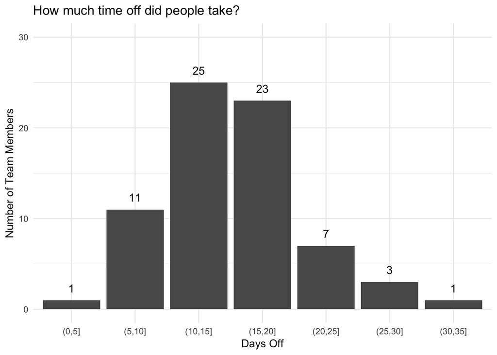

How does this look for people that live in different regions? Let’s look at the *median* number of vacation days taken by team members in each region.

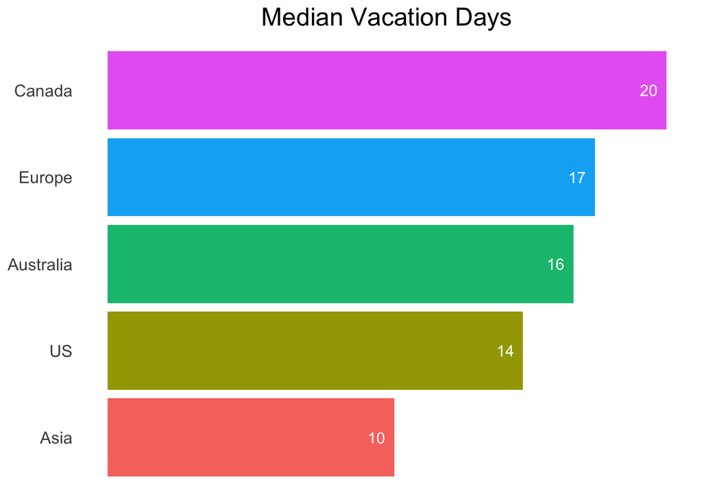

This is interesting! We haven’t yet taken into account the variance in the number of vacation days taken, so let’s visualize the distribution of vacation days taken from team members that live in each region.

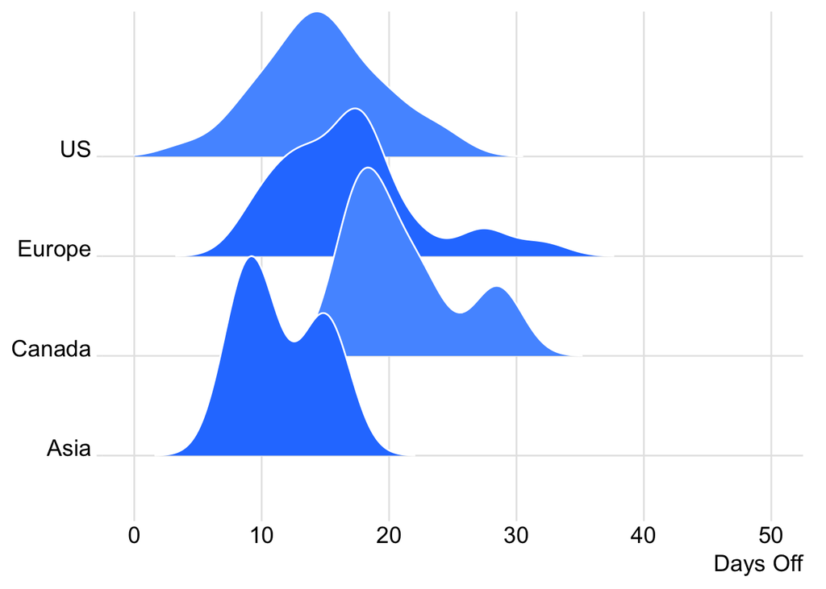

Team members in Asia represent a smaller sample, but their distribution is centered around 11 days.

### That’s it for now

That was fun! Let me know if you have any thoughts or questions!